# Promedio Movil

Rolando Fortanell

2025-03-04

Estimación de un modelo de promedio móvil para estimar la varianza

$$\sigma_{t, m}=\sum_{i=1}^m
R_{t-1}^2$$

```r
library(quantmod)
clave <- "GFNORTEO.MX"
datos <- new.env()
getSymbols(clave, env=datos)
```

```
## [1] "GFNORTEO.MX"
```

```r
precio <- datos[[clave]][,6]
rend <- na.omit(diff(log(precio)))
rend_c <- rend^2
```

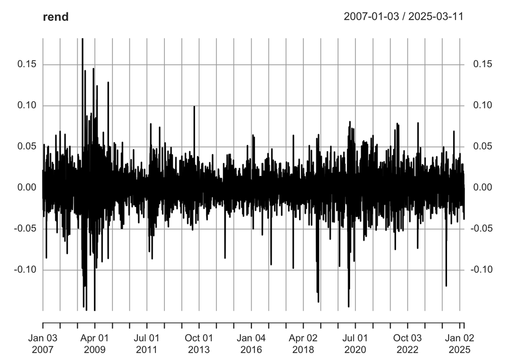

```r
plot(rend)
```

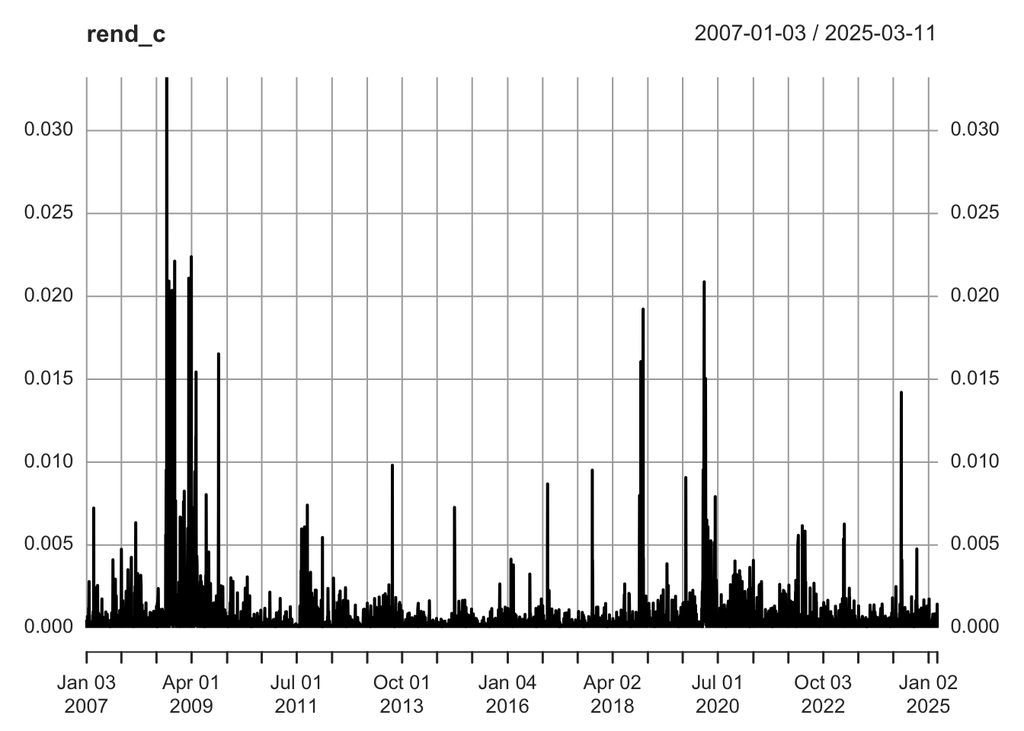

```r
plot(rend_c)
```

El rendimiento al cuadrado constituye la estimación mas sencilla de la varianza

```r
library(TTR)
Var_5 <- SMA(rend_c, n=6)
Var_10 <- SMA(rend_c, n=11)
Var_20 <- SMA(rend_c, n=21)
Var_40 <- SMA(rend_c, n=41)
```

Antes de decidir quien es M, vamos a graficar las estimaciones de varianza de cada modelo (en reealidad tenemos 4 modelos, todos promedios moviles, pero con diferentes valores de m)

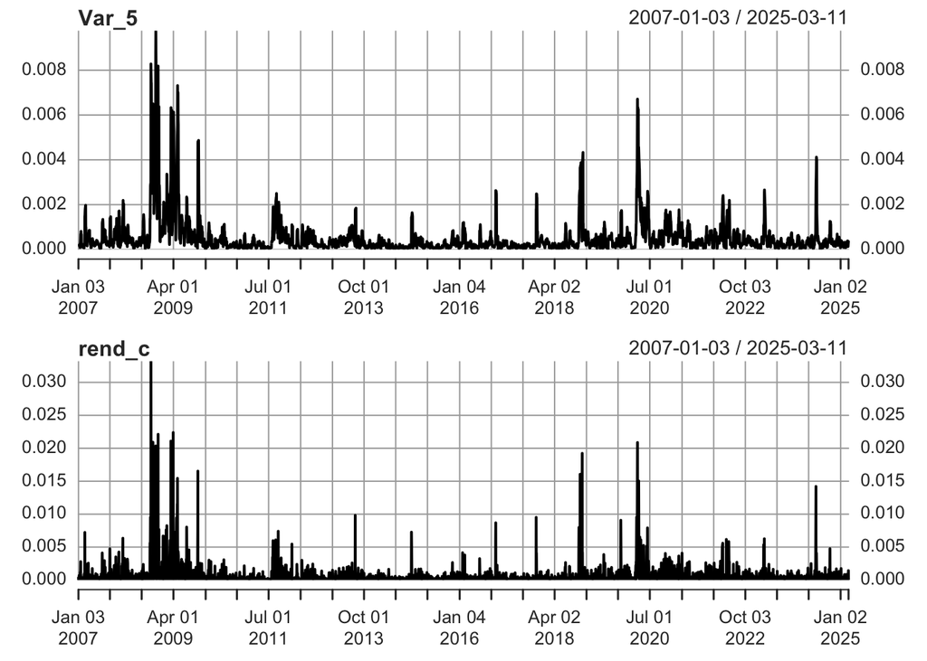

```r
layout(matrix(c(1,2)))
plot(Var_5)
plot(rend_c)
```

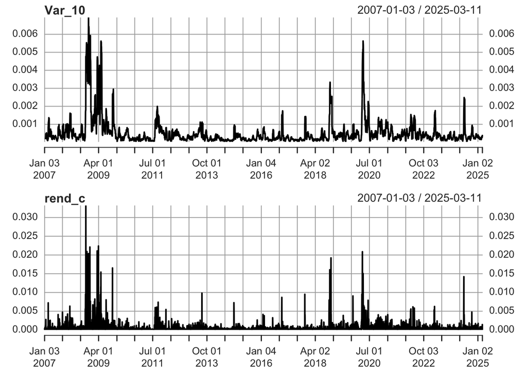

```r
layout(matrix(c(1,2)))
plot(Var_10)
plot(rend_c)
```

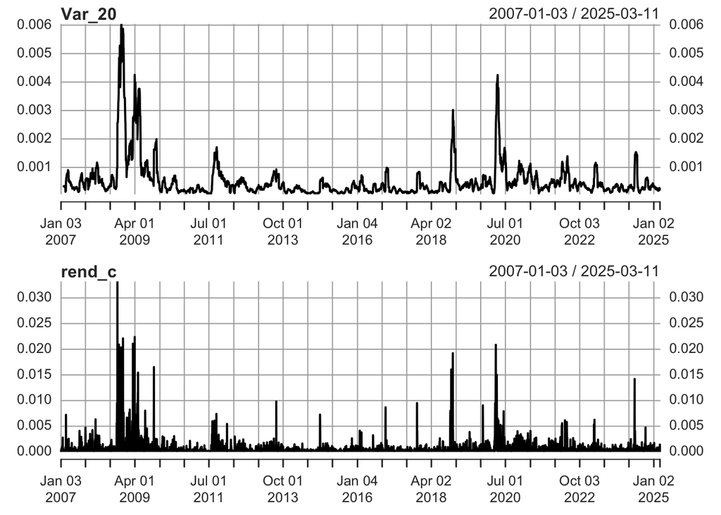

```r
layout(matrix(c(1,2)))
plot(Var_20)
plot(rend_c)
```

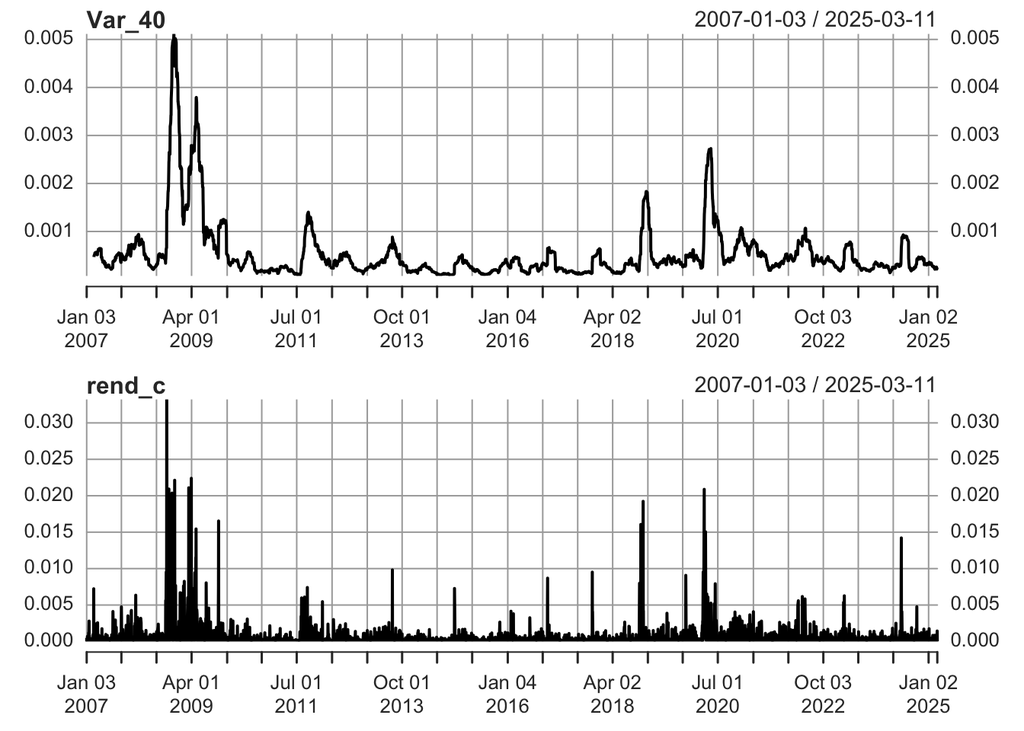

```r
layout(matrix(c(1,2)))
plot(Var_40)
plot(rend_c)
```

Para seleccionar el mejor valor de m, que produzca el menor error, usaremos tres indicadores:

RMSE

```r
library(tibble)
RMSE <- tibble(
  "m=5"=sqrt(mean((na.omit(rend_c - Var_5))^2)),
  "m=10"=sqrt(mean((na.omit(rend_c - Var_10))^2)),
  "m=20"=sqrt(mean((na.omit(rend_c - Var_20))^2)),
  "m=40"=sqrt(mean((na.omit(rend_c - Var_40))^2))
)
RMSE
```

```
## # A tibble: 1 × 4
##     `m=5`  `m=10`  `m=20`  `m=40`
##     <dbl>   <dbl>   <dbl>   <dbl>
## 1 0.00122 0.00129 0.00133 0.00138
```

De acuerdo a este indicador el mejor valor se obtiene on m=5

Calculamos otros dos indicadores para saber si se refuerza la idea de m=5 o es necesario cambiar

```r
EAMP <- tibble(
  "m=5"=mean(abs(na.omit(Var_5-rend_c))),
  "m=10"=mean(abs(na.omit(Var_10-rend_c))),
  "m=20"=mean(abs(na.omit(Var_20-rend_c))),
  "m=40"=mean(abs(na.omit(Var_40-rend_c)))
)
EAMP
```

```
## # A tibble: 1 × 4
##      `m=5`   `m=10`   `m=20`   `m=40`
##      <dbl>    <dbl>    <dbl>    <dbl>
## 1 0.000490 0.000523 0.000544 0.000560
```

Tambien me recomienda usar m=5

El tercer indicador es e ECPP, el cual consiste en proporcionalizar el error.

Nota: Como el indicar dice que es necesario dividir entre el rendimiento al cuadrado, vamos a calcular e valor del indicador y eliminar los valores que resulten infinitos ocasionados por el rendimiento cero.

```r
W <- merge.xts(((na.omit(Var_5-rend_c))/na.omit(rend_c))^2,
               ((na.omit(Var_10-rend_c))/na.omit(rend_c))^2,
               ((na.omit(Var_20-rend_c))/na.omit(rend_c))^2,
               ((na.omit(Var_40-rend_c))/na.omit(rend_c))^2
               )

W <- subset(W, W$SMA!="Inf")
```

```r
ECPP <- sqrt(colMeans(na.omit(W)))
```

Con esta primera conclusion del valor de m, vamos a construir una estimacion futura para la varianza en un dia despues del utlimo dia de informacion disponible.

```r
moptima <- 5
```

Hoy es

```r
library(lubridate)
fecha_est <- date(last(precio))+1
fecha_est
```

```
## [1] "2025-03-12"
```

Y mi estimacion es para hoy

Usando los ultimos 5 dias la estimacion de varianza es:

```r
mean(last(rend_c, moptima))
```

```
## [1] 0.0003394929
```

Por lo tanto, la estimacion de volatilidad es de

```r
v_est <- sqrt(mean(last(rend_c, moptima)))
v_est
```

```
## [1] 0.01842533
```

Por lo tanto, el valor optimo de m es 5, la estimacion de volatilidad usando este valor es de 1.8425334% y es para el dia 2025-03-12